# Machine Learning

## Supervised Learning with Decision Tree

#### Mageshwaran Anbazhagan

##### Overview:

A supervised machine learning algorithm that uses a decision tree to generate classification and regression models. The attributes are used to classify data in the decision tree. The tree is made up of decision nodes and decision leaves, with each node having two or more branches that indicate the value of the attribute being examined. The leaf nodes generate a homogeneous result. The ID3 algorithm follows a greedy approach by selecting a best attribute that provides maximum Information Gain or minimum Entropy.

##### Approach:

To find the entropy for the provided training dataset, we first constructed the entropy calculation function. We used the entropy calculation function to calculate the information gain once we found the entropy. The donut chart was then produced using the entropy and information gain values to illustrate the average number of positively and negatively responding patients for the new treatment. We also utilized a horizontal stacked bar chart to display the probability of positive and negative oracle for each attribute. By evaluating our program to the DecisionTreeClassifier() function in scikit.learn, we can ensure that it worked correctly on the Treatment dataset.

##### The packages required for execution are imported in this section of the code

```python
import pandas as pd
import math
import matplotlib.pyplot as plt
from treelib import Node, Tree
```

```python
fullDataset = pd.read_csv("/Users/mickey/Downloads/treatment.csv")
fullObj = pd.DataFrame(fullDataset)
```

##### Entropy for the entire training set is calculated using the Entropy_Calculation function created

##### This function finds the entropy for the entire dataset provided, at first it finds the unique target values and applies the entropy formula for each one of them separately

```python
def entropyCalculation (dataset):
    val = []
    entropy = 0
    graph = []
    uniqueValues = dataset.iloc[:,-1].unique()

    for uniqueVal in uniqueValues:
        totVal = 0
        temp = 0
        for target in dataset.iloc[:,-1]:
            if (target == uniqueVal):
                temp += 1
            totVal += 1
        val.append(temp)

    for value in range(0,len(uniqueValues)):
        temp = ( val[value] / totVal )
        graph.append(temp * 100)
        entropy -= temp * math.log2(temp)


    my_circle = plt.Circle( (0,0), 0.7, color='white')
    plt.pie(graph, labels=uniqueValues, autopct='%1.0f%%', pctdistance=1.1, labeldistance=1.2)
    p = plt.gcf()
    p.gca().add_artist(my_circle)
    plt.show()

    return entropy
```

##### Information Gain is calculated using the Entropy_Calculation function created

##### In this function information gain is calculated based on the individual entropy calculated for each attribute and then the entire predicted data is moved into a dictionary. This dictionary of entropy and information gain value is returned as output

```python
def attributeCalculation (dataset):
    attributeDict = {}
    truncData = fullObj
    truncData = truncData.iloc[:, :-1]
    for val in fullObj:
        lastColumn = val
    for column in truncData:
        uniqueValues = fullObj[column].unique()
        uniqueTarget = fullObj.iloc[:,-1].unique()
        attributeDict[column] = {}
        for uniqueVal in uniqueValues:
            attributeDict[column][uniqueVal] = {}
            for unique in uniqueTarget:
                temp = 0
                for index, row in fullObj.iterrows():
                    if ((row[column] == uniqueVal) and (row[lastColumn] == unique)):
                        temp += 1
                attributeDict[column][uniqueVal][unique] = temp
    for i in attributeDict:
        for j in attributeDict[i]:
            temp = 0
            for k in attributeDict[i][j]:
                temp += attributeDict[i][j][k]
            attributeDict[i][j]["Total"] = temp
    for i in attributeDict:
        for j in attributeDict[i]:
            temp = 0
            for k in fullObj.iloc[:,-1].unique():
                if ((attributeDict[i][j][k]) == 0):
                    temp -= 0
                else:
                    temp -=  (((attributeDict[i][j][k]) / (attributeDict[i][j]["Total"]))) * math.log2(((attributeDict[i][j][k]) / (attributeDict[i][j]["Total"])))
            attributeDict[i][j]["Entropy"] = temp
    fullEntropy = entropyCalculation(fullObj)
    for i in attributeDict:
        temp = fullEntropy
        for j in attributeDict[i]:
            temp -= (attributeDict[i][j]["Total"]) / (len(fullObj)) * attributeDict[i][j]["Entropy"]
        attributeDict[i]["Gain"] = temp
    return (attributeDict)
```

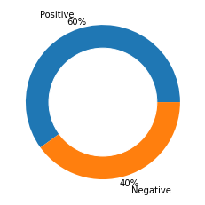

```
{'Pulse': {'NormalPulse': {'Positive': 2,
   'Negative': 1,
   'Total': 3,
   'Entropy': 0.9182958340544896},
  'RapidPulse': {'Positive': 1, 'Negative': 1, 'Total': 2, 'Entropy': 1.0},
  'Gain': 0.01997309402197489},
 'Blood Pressure': {'NormalBP': {'Positive': 3,
   'Negative': 0,
   'Total': 3,
   'Entropy': 0.0},
  'HighBP': {'Positive': 0, 'Negative': 2, 'Total': 2, 'Entropy': 0.0},
  'Gain': 0.9709505944546686},
 'Age Level': {'Young': {'Positive': 1,
   'Negative': 0,
   'Total': 1,
   'Entropy': 0.0},
  'Middle': {'Positive': 1, 'Negative': 0, 'Total': 1, 'Entropy': 0.0},
  'Old': {'Positive': 1,
   'Negative': 2,
   'Total': 3,
   'Entropy': 0.9182958340544896},
  'Gain': 0.4199730940219749}}
```

```python
finalAttribute = attributeCalculation(fullObj)
finalAttribute
```

##### Visualization of the distribution of target value on the provided dataset

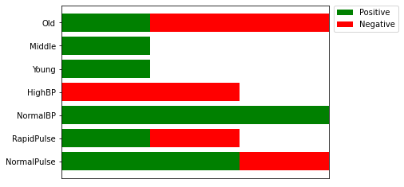

```python
uniqueValues = fullObj.iloc[:,-1].unique()
count = 0
classVal = []
positive = []
negative = []
for i in finalAttribute:
    for j in finalAttribute[i]:
        if j != "Gain":
            classVal.append(j)
            for k in range(0,len(uniqueValues)):
                dump = uniqueValues[k]
                if k == 0:
                    positive.append(finalAttribute[i][j][dump])
                else:
                    negative.append(finalAttribute[i][j][dump])
        else:
            continue

b1 = plt.barh(classVal, positive, color="green")

b2 = plt.barh(classVal, negative, left=positive, color="red")

b3 = plt.legend([b1, b2], ["Positive", "Negative"], bbox_to_anchor=(1.02, 1), loc='upper left', borderaxespad=0)

b3.axes.get_xaxis().set_visible(False)

plt.show()
```

```python
pd.set_option("max_colwidth", 400)
pd.DataFrame.from_dict(finalAttribute).fillna("Not Applicable")
```

|  | Pulse | Blood Pressure | Age Level |
| --- | --- | --- | --- |
| NormalPulse | {'Positive': 2, 'Negative': 1, 'Total': 3, 'Entropy': 0.9182958340544896} | Not Applicable | Not Applicable |
| RapidPulse | {'Positive': 1, 'Negative': 1, 'Total': 2, 'Entropy': 1.0} | Not Applicable | Not Applicable |
| Gain | 0.019973 | 0.970951 | 0.419973 |
| NormalBP | Not Applicable | {'Positive': 3, 'Negative': 0, 'Total': 3, 'Entropy': 0.0} | Not Applicable |
| HighBP | Not Applicable | {'Positive': 0, 'Negative': 2, 'Total': 2, 'Entropy': 0.0} | Not Applicable |
| Young | Not Applicable | Not Applicable | {'Positive': 1, 'Negative': 0, 'Total': 1, 'Entropy': 0.0} |
| Middle | Not Applicable | Not Applicable | {'Positive': 1, 'Negative': 0, 'Total': 1, 'Entropy': 0.0} |
| Old | Not Applicable | Not Applicable | {'Positive': 1, 'Negative': 2, 'Total': 3, 'Entropy': 0.9182958340544896} |

```python
def splitColumn (finalAttribute):
    splitDict = {}
    for i in finalAttribute:
        splitDict[i] = finalAttribute[i]["Gain"]
    findMax = max(splitDict, key=splitDict.get)
    return(findMax)
```

```python
findMax = splitColumn(finalAttribute)
names = fullObj[findMax].unique().tolist()
DataframeSplitList = []
treeData = []
finalSplit = []
counter = 1
uniqueFindMax = fullObj[findMax].unique()
finalList = []
for val in fullObj:
    lastColumn = val
d = fullObj.groupby([findMax,lastColumn]).size()
print(findMax,end="\n")
for i in uniqueFindMax:
    print(i,end = "\n")
    for j in uniqueValues:
        strVal = ""
        count = 0
        for index,row in fullObj.iterrows():
            if ((row[findMax] == i) and (row[lastColumn] == j)):
                strVal = strVal +" "+ str(index + 1)
                count += 1
        if count > 0:
            print(j+strVal)
```

```
Blood Pressure
NormalBP
Positive 1 2 3
HighBP
Negative 4 5
```

##### Decision Tree is manually plotted with the help of a treelib package

```python
tree = Tree()
tree.create_node("Blood Pressure", "BP")
tree.create_node("Normal Blood Pressure",  "NBP"   , parent="BP")
tree.create_node("High Blood Pressure",  "HBP"   , parent="BP")
tree.create_node("Positive (1,2,3)", "Nm", parent = "NBP")
tree.create_node("Negative (4,5)","Nmm",parent = "HBP")
tree.show()
```

```
Blood Pressure
├── High Blood Pressure
│   └── Negative (4,5)
└── Normal Blood Pressure
    └── Positive (1,2,3)
```

##### The DecisionTreeClassifier function from sklearn package is used to verify the model which was predicted

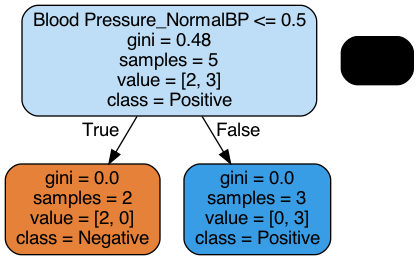

```python
from sklearn import tree
import pandas as pd
import pydotplus
from IPython.display import Image
import collections


categoricalToNumerical = pd.get_dummies(fullObj[ ['Pulse', 'Blood Pressure', 'Age Level'] ])

clf = tree.DecisionTreeClassifier()

clf_train = clf.fit(categoricalToNumerical, fullObj['Treatment'])

exportVal = tree.export_graphviz(clf_train, out_file=None, feature_names=list(categoricalToNumerical.columns.values),
                                class_names=['Negative', 'Positive'], rounded=True, filled=True)

finalGraph = pydotplus.graph_from_dot_data(exportVal)

Image(finalGraph.create_png())
```